# Biostat 203B Homework 4

Due Mar 18 @ 11:59PM

Yi Fang

Load database libraries and the tidyverse frontend:

```r
suppressPackageStartupMessages(library(tidyverse))
suppressPackageStartupMessages(library(lubridate))
suppressPackageStartupMessages(library(miceRanger))
```

## Q1. Missing data

Through the Shiny app developed in HW3, we observe abundant missing values in the MIMIC-IV ICU cohort we created. In this question, we use multiple imputation to obtain a data set without missing values.

0. Read following tutorials on the R package miceRanger for imputation: https://github.com/farrellday/miceRanger, https://cran.r-project.org/web/packages/miceRanger/vignettes/miceAlgorithm.html.

   A more thorough book treatment of the practical imputation strategies is the book [*Flexible Imputation of Missing Data*](https://stefvanbuuren.name/fimd/) by Stef van Buuren.
1. Explain the jargon MCAR, MAR, and MNAR.

If the probability of being missing is the same for all cases, then the data are said to be missing completely at random (MCAR). If the probability of being missing is the same only within groups defined by the observed data, then the data are missing at random (MAR). If neither MCAR nor MAR holds, then we speak of missing not at random (MNAR). MNAR means that the probability of being missing varies for reasons that are unknown to us.

2. Explain in a couple of sentences how the Multiple Imputation by Chained Equations (MICE) work.

Multiple Imputation by Chained Equations is a robust, informative method of dealing with missing data in datasets. The procedure ‘fills in’ (imputes) missing data in a dataset through an iterative series of predictive models. In each iteration, each specified variable in the dataset is imputed using the other variables in the dataset. These iterations should be run until it appears that convergence has been met.

3. Perform a data quality check of the ICU stays data. Discard variables with substantial missingness, say >5000 `NA`s. Replace apparent data entry errors by `NA`s.

First, I manually check which data have substantial missingness, and I find that `marital status` and `calcium` are 2 variables with more than 4000 missing value, so I only keep the variables that are related. Then, I check the remainning variables, and I do not find any apparent data entry errors, so I do not replace apparent data entry errors by `NA`s.

```r
icu_cohort <- readRDS("~/homework-203B-2022-Winter/hw3/mimiciv_shiny/icu_cohort.rds")
colSums(is.na(icu_cohort))
```

```
##                           subject_id                               intime
##                                    0                                    0
##                              hadm_id                              stay_id
##                                    0                                    0
##                       first_careunit                        last_careunit
##                                    0                                    0
##                              outtime                                  los
##                                    0                                    0
##                            admittime                            dischtime
##                                    0                                    0
##                            deathtime                       admission_type
##                                47558                                    0
##                   admission_location                   discharge_location
##                                    0                                  492
##                            insurance                             language
##                                    0                                    0
##                       marital_status                            ethnicity
##                                 4617                                    0
##                            edregtime                            edouttime
##                                19613                                19613
##                 hospital_expire_flag                               gender
##                                    0                                    0
##                           anchor_age                          anchor_year
##                                    0                                    0
##                    anchor_year_group                                  dod
##                                    0                                45148
##                   charttime_labevent                            magnesium
##                                 1520                                 2854
##                           hematocrit                            potassium
##                                 2019                                 1780
##                               sodium               white_blood_cell_count
##                                 1749                                 2142
##                          bicarbonate                              calcium
##                                 1795                                 4324
##                             chloride                           creatinine
##                                 1756                                 1775
##                              glucose                 charttime_chartevent
##                                 1870                                   14
##       body_temperature_in_Fahrenheit systolic_non_invasive_blood_pressure
##                                  956                                  684
##     mean_non_invasive_blood_pressure                     respiratory_rate
##                                  705                                   62
##                           heart_rate                             age_hadm
##                                   16                                    0
##                           hadm_death                      thirty_day_mort
##                                45148                                45148
##                           thirty_day
##                                    0
```

4. Impute missing values by `miceRanger` (request $m=3$ data sets). This step is computational intensive. Make sure to save the imputation results as a file. Hint: Setting `max.depth=10` in the `miceRanger` function may cut some computing time.

```r
# icu_cohort <- icu_cohort %>%
#   select(ethnicity,
#   language,
#   insurance,
#   gender,
#   first_careunit,
#   anchor_age,
#   creatinine,
#   potassium,
#   sodium,
#   chloride,
#   bicarbonate,
#   hematocrit,
#   white_blood_cell_count,
#   glucose,
#   magnesium,
#   heart_rate,
#   mean_non_invasive_blood_pressure,
#   systolic_non_invasive_blood_pressure,
#   body_temperature_in_Fahrenheit,
#   respiratory_rate,
#   thirty_day)
#
# mice <- miceRanger(
#    icu_cohort,
#    m=3,
#    returnModels = FALSE,
#    verbose = FALSE,
#    max.depth=10)
#
# write_rds(mice, "~/homework-203B-2022-Winter/hw4/mice.rds")
```

5. Make imputation diagnostic plots and explain what they mean.

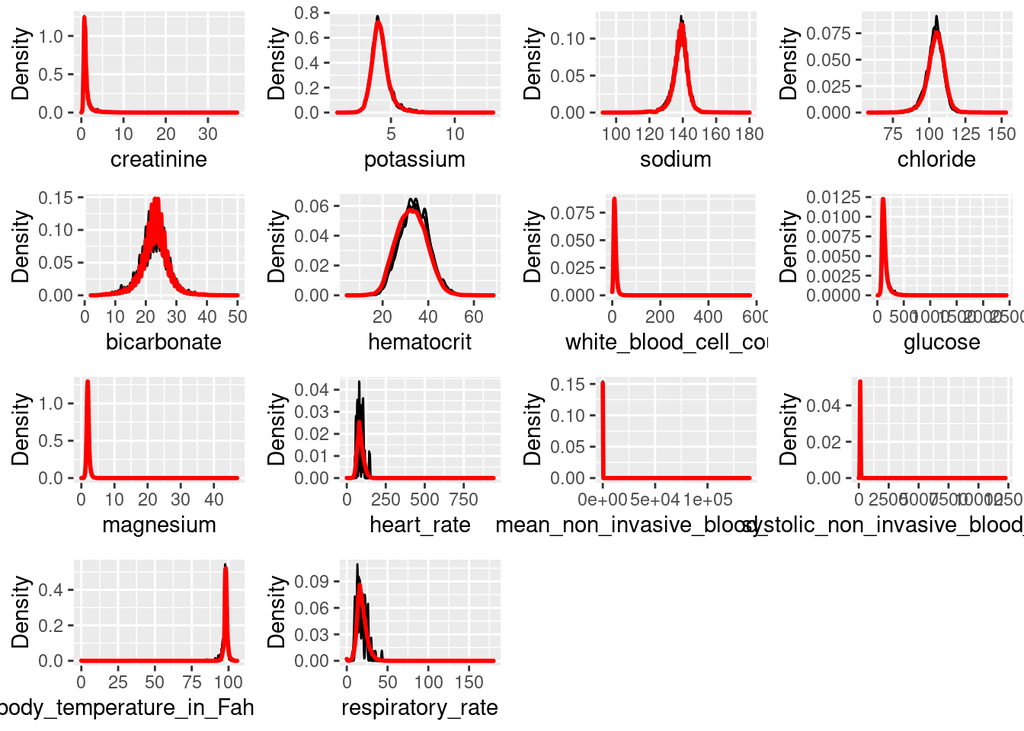

```r
mice <- readRDS("~/homework-203B-2022-Winter/hw4/mice.rds")
plotDistributions(mice)
```

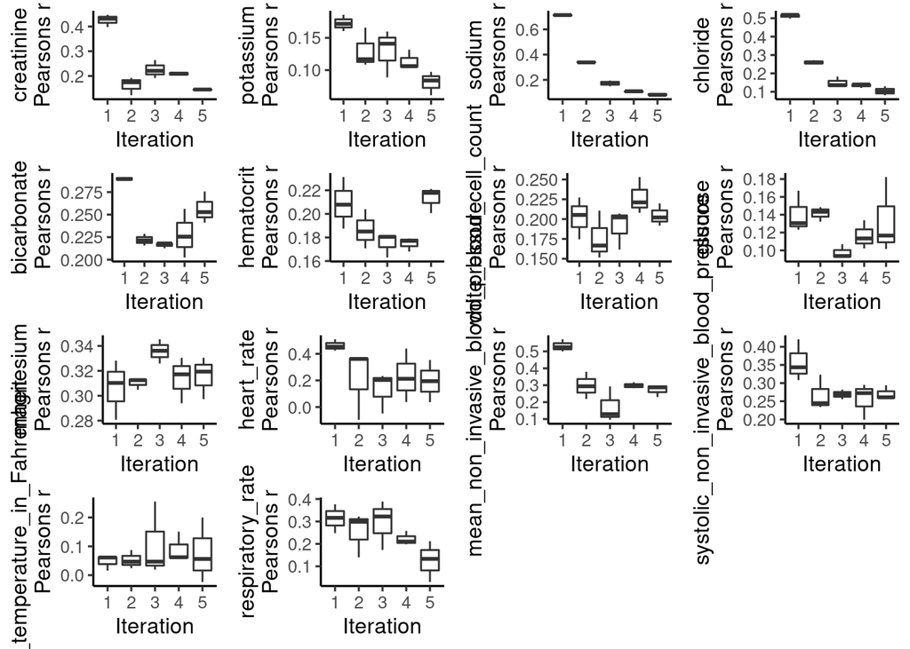

```r
plotCorrelations(mice)
```

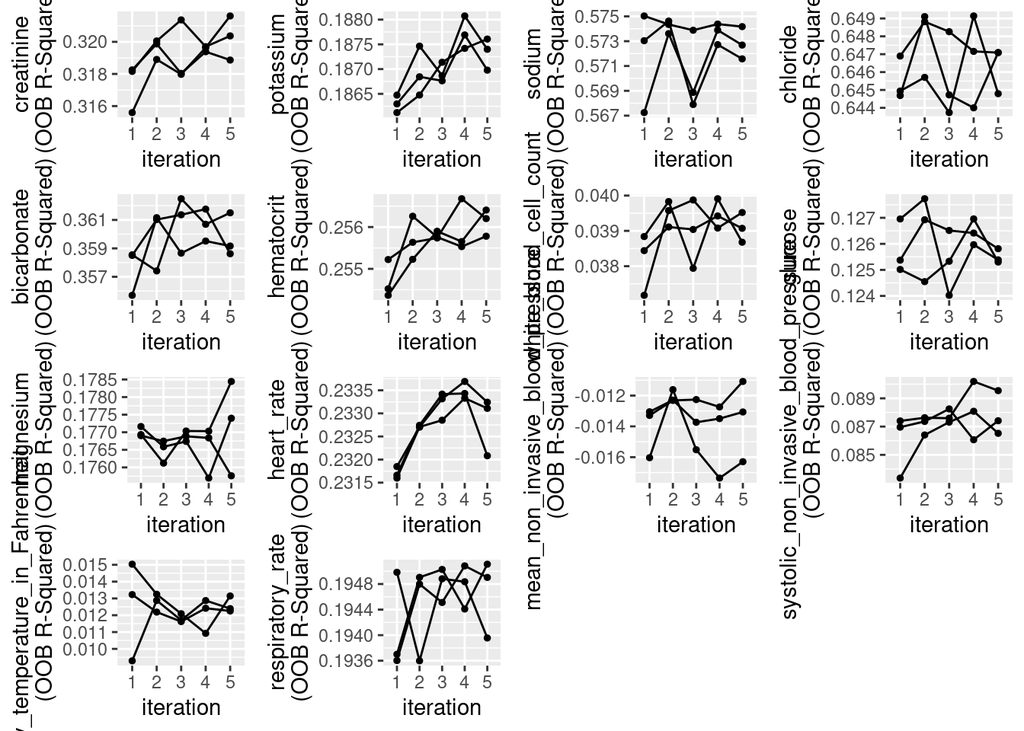

```r
plotModelError(mice)
```

The distribution plot of imputed values are created first. The red lines are the original data, and the 3 black lines are the imputed values after the MICE. We can find that in almost all variables, the data matches pretty well. The second plot is the correlation plot. This plot shows a boxplot of the correlations between imputed values in every combination of datasets, at each iteration. Finally, I plot a OOB error plot. Each model returns the OOB accuracy for classification, and r-squared for regression. We can find that the accuracy for most of the variable are not that good.

6. Choose one of the imputed data sets to be used in Q2. This is **not** a good idea to use just one imputed data set or to average multiple imputed data sets. Explain in a couple of sentences what the correct Multiple Imputation strategy is.

I choose to use the first imputed data set in Q2. We do not want to use a single data set, because a single data set may not be perfect or accurate. We want to use different imputed data sets, and analysis all the data sets, then integrate the result of all the data sets. I will use only one data set in this homework for the time reason.

## Q2. Predicting 30-day mortality

Develop at least two analytic approaches for predicting the 30-day mortality of patients admitted to ICU using demographic information (gender, age, marital status, ethnicity), first lab measurements during ICU stay, and first vital measurements during ICU stay. For example, you can use (1) logistic regression (`glm()` function in base R or keras), (2) logistic regression with lasso penalty (glmnet or keras package), (3) random forest (randomForest package), or (4) neural network (keras package).

First, select the first MICE from the 3 MICE result.

```r
data <- completeData(mice)
data <- data[[1]]
data
```

```
##                     ethnicity language insurance gender
##     1:                  OTHER  ENGLISH  Medicare      M
##     2:                  OTHER  ENGLISH     Other      F
##     3:                  WHITE  ENGLISH     Other      F
##     4:                  WHITE  ENGLISH     Other      F
##     5: BLACK/AFRICAN AMERICAN  ENGLISH     Other      M
##    ---
## 53061:                  WHITE  ENGLISH     Other      M
## 53062:                  OTHER  ENGLISH  Medicaid      F
## 53063:                  WHITE  ENGLISH  Medicare      F
## 53064:                  WHITE  ENGLISH     Other      F
## 53065:                  WHITE  ENGLISH  Medicare      F
##                                          first_careunit anchor_age creatinine
##     1:                                   Neuro Stepdown         72        1.0
##     2:                                   Neuro Stepdown         49        0.5
```

[output cut: 57 more lines]

1. Partition data into 80% training set and 20% test set. Stratify partitioning according the 30-day mortality status.

```r
library(caret)
set.seed(3456)
trainIndex <- createDataPartition(data$thirty_day, p=0.8, list=FALSE)
data_train <- data[trainIndex,]
data_test <- data[-trainIndex,]
```

1. Logistic regression.
2. Train the models using the training set.

```r
log_model <- glm(thirty_day~., data = data_train, family = 'binomial')
summary(log_model)
```

```
##
## Call:
## glm(formula = thirty_day ~ ., family = "binomial", data = data_train)
##
## Deviance Residuals:
##     Min       1Q   Median       3Q      Max
## -3.5995  -0.4727  -0.3224  -0.2036   8.4904
##
## Coefficients:
##                                                                  Estimate
## (Intercept)                                                    -5.101e+00
## ethnicityASIAN                                                  3.960e-01
## ethnicityBLACK/AFRICAN AMERICAN                                 9.850e-02
## ethnicityHISPANIC/LATINO                                        2.763e-01
## ethnicityOTHER                                                  3.763e-01
## ethnicityUNABLE TO OBTAIN                                       1.331e+00
## ethnicityUNKNOWN                                                1.191e+00
## ethnicityWHITE                                                  2.852e-01
## languageENGLISH                                                 1.229e-01
## insuranceMedicare                                              -1.593e-01
## insuranceOther                                                 -1.809e-01
## genderM                                                         4.489e-02
## first_careunitCoronary Care Unit (CCU)                          1.106e+00
## first_careunitMedical Intensive Care Unit (MICU)                1.389e+00
## first_careunitMedical/Surgical Intensive Care Unit (MICU/SICU)  1.276e+00
## first_careunitNeuro Intermediate                               -1.796e-01
## first_careunitNeuro Stepdown                                   -1.324e-01
## first_careunitNeuro Surgical Intensive Care Unit (Neuro SICU)   1.546e+00
## first_careunitSurgical Intensive Care Unit (SICU)               1.424e+00
## first_careunitTrauma SICU (TSICU)                               1.168e+00
## anchor_age                                                      3.526e-02
## creatinine                                                     -5.881e-03
## potassium                                                       1.476e-01
## sodium                                                          8.890e-02
## chloride                                                       -8.905e-02
## bicarbonate                                                    -1.179e-01
## hematocrit                                                     -1.232e-02
## white_blood_cell_count                                          1.181e-02
## glucose                                                         1.051e-03
## magnesium                                                       1.619e-01
```

[output cut: 108 more lines]

```
## heart_rate                                                     ***
## mean_non_invasive_blood_pressure                               *
## systolic_non_invasive_blood_pressure                           ***
## body_temperature_in_Fahrenheit                                 ***
## respiratory_rate                                               ***
## ---
## Signif. codes:  0 '***' 0.001 '**' 0.01 '*' 0.05 '.' 0.1 ' ' 1
##
## (Dispersion parameter for binomial family taken to be 1)
##
##     Null deviance: 28050  on 42451  degrees of freedom
## Residual deviance: 23462  on 42417  degrees of freedom
## AIC: 23532
##
## Number of Fisher Scoring iterations: 6
```

3. Compare model prediction performance on the test set.

```r
prob_log <- predict(log_model, data_test, type = "response")
predict_log <- ifelse(prob_log > 0.5, TRUE, FALSE)
table(observed = data_test$thirty_day, predicted = predict_log)
```

```
##         predicted
## observed FALSE TRUE
##    FALSE  9458   68
##    TRUE    988   99
```

```r
cat("Test Accuracy", mean(predict_log == data_test$thirty_day))
```

```
## Test Accuracy 0.9004994
```

2. Logistic regression with lasso penalty using glmnet package.
2. Train the models using the training set.

```r
library(glmnet)
cv.out <- cv.glmnet(model.matrix(thirty_day ~ ., data_train),
                    data_train$thirty_day,
                    alpha = 1, family = "binomial", type.measure = "mse")
cv.out
```

```
##
## Call:  cv.glmnet(x = model.matrix(thirty_day ~ ., data_train), y = data_train$thirty_day,      type.measure = "mse", alpha = 1, family = "binomial")
##
## Measure: Mean-Squared Error
##
##        Lambda Index Measure       SE Nonzero
## min 0.0000695    71  0.1608 0.001406      33
## 1se 0.0026160    32  0.1621 0.001452      27
```

```r
lasso_min <- cv.out$lambda.min
lasso_lse <- cv.out$lambda.1se
coef(cv.out, s = lasso_lse)
```

```
## 36 x 1 sparse Matrix of class "dgCMatrix"
##                                                                           s1
## (Intercept)                                                    -3.393335e+00
## (Intercept)                                                     .
## ethnicityASIAN                                                  .
## ethnicityBLACK/AFRICAN AMERICAN                                -6.273744e-02
## ethnicityHISPANIC/LATINO                                        .
## ethnicityOTHER                                                  .
## ethnicityUNABLE TO OBTAIN                                       7.704867e-01
## ethnicityUNKNOWN                                                8.323918e-01
## ethnicityWHITE                                                  .
## languageENGLISH                                                 .
## insuranceMedicare                                               .
## insuranceOther                                                 -2.306278e-04
## genderM                                                         .
## first_careunitCoronary Care Unit (CCU)                          2.847427e-01
## first_careunitMedical Intensive Care Unit (MICU)                5.688825e-01
## first_careunitMedical/Surgical Intensive Care Unit (MICU/SICU)  4.384570e-01
## first_careunitNeuro Intermediate                               -4.395059e-01
## first_careunitNeuro Stepdown                                   -2.332781e-01
## first_careunitNeuro Surgical Intensive Care Unit (Neuro SICU)   6.125260e-01
## first_careunitSurgical Intensive Care Unit (SICU)               5.421656e-01
## first_careunitTrauma SICU (TSICU)                               2.922400e-01
## anchor_age                                                      3.166790e-02
## creatinine                                                      1.520208e-02
## potassium                                                       1.090633e-01
## sodium                                                          6.219393e-02
## chloride                                                       -6.884744e-02
## bicarbonate                                                    -1.072467e-01
## hematocrit                                                     -2.127299e-03
## white_blood_cell_count                                          1.109028e-02
## glucose                                                         9.925555e-04
## magnesium                                                       3.638883e-02
## heart_rate                                                      8.225660e-03
## mean_non_invasive_blood_pressure                                3.488527e-06
## systolic_non_invasive_blood_pressure                           -1.969600e-04
## body_temperature_in_Fahrenheit                                 -2.573952e-02
## respiratory_rate                                                3.006049e-02
```

3. Compare model prediction performance on the test set.

```r
prob_lasso <-
  predict(cv.out,
          newx = model.matrix(data_test$thirty_day ~ ., data_test),
          s = lasso_lse, type = "response")
predict_lasso <- ifelse(prob_lasso > 0.5, TRUE, FALSE)
table(observed = data_test$thirty_day, predicted = predict_lasso)
```

```
##         predicted
## observed FALSE TRUE
##    FALSE  9492   34
##    TRUE   1022   65
```

```r
cat("Test Accuracy", mean(predict_lasso == data_test$thirty_day))
```

```
## Test Accuracy 0.9004994
```